# Exploratory

## Introduction

The Aviation industry is one of the largest and most active industries moving millions of people around thw world. Efficiency and safety are priority in the industry and anything less is not acceptable.

The dataset under investigation is the flight data which contain key details for domestic flights in USA for 2019. The data was obtained from the Bureau of Transportation Statistics which contains large volume of information on various transportation methods. The dataset consist of about 48 columns which include tail number, carrier code, destination and origin airport, arrival and departure delay, causes of delay e.t.c

Using the dataset we will try to review key infromation regarding the performance of the aviation industry in 2019.

## Import all necessary packages

```python
import pandas as pd
import numpy as np
from numpy import nan
import glob
import matplotlib.pyplot as plt
import seaborn as sns
sns.set_style('darkgrid')
plt.style.use('seaborn')
%matplotlib inline
```

## Data Gathering

The first step was to download the dataset month by month for 2019. After downloading the monthly data was merged through the following steps; glob package was used to iterate through the monthly data, pandas read function used to read the monthly data and the pandas concat fnction was used to merger into a large data set (air_time.csv).

Note: Due to the data size and internet connectivity only the dataset for 2019 could be downloaded.

###### # Read monthly CSV files and merge all into a singe csv file (air_time)

path = r'C:\Users\Dfadokun\Downloads\New folder\project5' data_files = glob.glob(path + "/*.csv")

data = []

for filename in data_files: df = pd.read_csv(filename, index_col=None, header=0 , ) data.append(df)

air_time = pd.concat(data, axis=0)

###### # Select some specific column initially to reduce data size

air_time = air_time.loc[:,['FL_DATE','OP_UNIQUE_CARRIER', 'TAIL_NUM', 'OP_CARRIER_FL_NUM', 'ORIGIN', 'ORIGIN_CITY_NAME','ORIGIN_STATE_NM','DEST','DEST_CITY_NAME', 'DEST_STATE_NM', 'CRS_DEP_TIME','DEP_TIME', 'DEP_DELAY', 'DEP_DELAY_NEW', 'TAXI_OUT', 'WHEELS_OFF', 'WHEELS_ON', 'TAXI_IN','CRS_ARR_TIME', 'ARR_TIME', 'ARR_DELAY', 'ARR_DELAY_NEW','CANCELLED','CANCELLATION_CODE', 'DIVERTED', 'CRS_ELAPSED_TIME','ACTUAL_ELAPSED_TIME', 'AIR_TIME', 'DISTANCE','CARRIER_DELAY', 'WEATHER_DELAY', 'NAS_DELAY', 'SECURITY_DELAY', 'LATE_AIRCRAFT_DELAY']]

air_time.info()

Note: Although this is a part of data cleaning, this was done to improve processing speed

air_time.to_csv('air_time.csv')

```python
# Read air_time.csv file
air_time = pd.read_csv('air_time.csv',index_col=False)
```

## Assess Data

In this phase I basically used pandas data assessment function to review data characteristic and also looking out for areas that might require cleaning.

```python
air_time.info()
```

```
<class 'pandas.core.frame.DataFrame'>
RangeIndex: 7422037 entries, 0 to 7422036
Data columns (total 35 columns):
Unnamed: 0             int64
FL_DATE                object
OP_UNIQUE_CARRIER      object
TAIL_NUM               object
OP_CARRIER_FL_NUM      int64
ORIGIN                 object
ORIGIN_CITY_NAME       object
ORIGIN_STATE_NM        object
DEST                   object
DEST_CITY_NAME         object
DEST_STATE_NM          object
CRS_DEP_TIME           int64
DEP_TIME               float64
DEP_DELAY              float64
DEP_DELAY_NEW          float64
TAXI_OUT               float64
WHEELS_OFF             float64
WHEELS_ON              float64
TAXI_IN                float64
CRS_ARR_TIME           int64
ARR_TIME               float64
ARR_DELAY              float64
ARR_DELAY_NEW          float64
CANCELLED              float64
CANCELLATION_CODE      object
DIVERTED               float64
CRS_ELAPSED_TIME       float64
ACTUAL_ELAPSED_TIME    float64
AIR_TIME               float64
DISTANCE               float64
CARRIER_DELAY          float64
WEATHER_DELAY          float64
NAS_DELAY              float64
SECURITY_DELAY         float64
LATE_AIRCRAFT_DELAY    float64
dtypes: float64(21), int64(4), object(10)
memory usage: 1.9+ GB
```

```python
pd.set_option('max_columns', None)
pd.set_option('max_rows',500)
pd.set_option('display.width', None)
air_time.drop('Unnamed: 0',axis=1,inplace=True)
```

```python
air_time.describe()
```

|  | OP_CARRIER_FL_NUM | CRS_DEP_TIME | DEP_TIME | DEP_DELAY | DEP_DELAY_NEW | TAXI_OUT | WHEELS_OFF | WHEELS_ON | TAXI_IN | CRS_ARR_TIME | ARR_TIME | ARR_DELAY | ARR_DELAY_NEW | CANCELLED | DIVERTED | CRS_ELAPSED_TIME | ACTUAL_ELAPSED_TIME | AIR_TIME | DISTANCE | CARRIER_DELAY | WEATHER_DELAY | NAS_DELAY | SECURITY_DELAY | LATE_AIRCRAFT_DELAY |
| --- | --- | --- | --- | --- | --- | --- | --- | --- | --- | --- | --- | --- | --- | --- | --- | --- | --- | --- | --- | --- | --- | --- | --- | --- |
| count | 7.422037e+06 | 7.422037e+06 | 7.291951e+06 | 7.291927e+06 | 7.291927e+06 | 7.288060e+06 | 7.288060e+06 | 7.284390e+06 | 7.284390e+06 | 7.422037e+06 | 7.284391e+06 | 7.268232e+06 | 7.268232e+06 | 7.422037e+06 | 7.422037e+06 | 7.421902e+06 | 7.268232e+06 | 7.268232e+06 | 7.422037e+06 | 1.389253e+06 | 1.389253e+06 | 1.389253e+06 | 1.389253e+06 | 1.389253e+06 |
| mean | 2.557196e+03 | 1.330259e+03 | 1.334606e+03 | 1.092327e+01 | 1.410478e+01 | 1.738935e+01 | 1.358264e+03 | 1.459032e+03 | 7.740776e+00 | 1.485790e+03 | 1.462955e+03 | 5.414849e+00 | 1.416780e+01 | 1.817897e-02 | 2.543776e-03 | 1.419022e+02 | 1.366903e+02 | 1.115734e+02 | 8.005437e+02 | 2.112859e+01 | 3.802404e+00 | 1.658795e+01 | 9.608329e-02 | 2.740748e+01 |
| std | 1.799413e+03 | 4.929855e+02 | 5.071998e+02 | 4.895964e+01 | 4.789598e+01 | 1.000398e+01 | 5.088109e+02 | 5.378414e+02 | 6.194340e+00 | 5.214659e+02 | 5.424542e+02 | 5.106666e+01 | 4.764549e+01 | 1.335983e-01 | 5.037167e-02 | 7.234685e+01 | 7.261274e+01 | 7.056123e+01 | 5.925118e+02 | 6.610465e+01 | 3.236297e+01 | 3.966440e+01 | 3.358346e+00 | 5.345620e+01 |
| min | 1.000000e+00 | 1.000000e+00 | 1.000000e+00 | -8.200000e+01 | 0.000000e+00 | 1.000000e+00 | 1.000000e+00 | 1.000000e+00 | 1.000000e+00 | 1.000000e+00 | 1.000000e+00 | -9.900000e+01 | 0.000000e+00 | 0.000000e+00 | 0.000000e+00 | 1.000000e+00 | 1.500000e+01 | 4.000000e+00 | 3.100000e+01 | 0.000000e+00 | 0.000000e+00 | 0.000000e+00 | 0.000000e+00 | 0.000000e+00 |
| 25% | 1.025000e+03 | 9.130000e+02 | 9.140000e+02 | -5.000000e+00 | 0.000000e+00 | 1.100000e+01 | 9.300000e+02 | 1.042000e+03 | 4.000000e+00 | 1.100000e+03 | 1.046000e+03 | -1.500000e+01 | 0.000000e+00 | 0.000000e+00 | 0.000000e+00 | 9.000000e+01 | 8.400000e+01 | 6.000000e+01 | 3.690000e+02 | 0.000000e+00 | 0.000000e+00 | 0.000000e+00 | 0.000000e+00 | 0.000000e+00 |
| 50% | 2.158000e+03 | 1.321000e+03 | 1.327000e+03 | -2.000000e+00 | 0.000000e+00 | 1.500000e+01 | 1.340000e+03 | 1.500000e+03 | 6.000000e+00 | 1.515000e+03 | 1.504000e+03 | -6.000000e+00 | 0.000000e+00 | 0.000000e+00 | 0.000000e+00 | 1.240000e+02 | 1.190000e+02 | 9.300000e+01 | 6.400000e+02 | 0.000000e+00 | 0.000000e+00 | 2.000000e+00 | 0.000000e+00 | 3.000000e+00 |
| 75% | 3.917000e+03 | 1.736000e+03 | 1.746000e+03 | 7.000000e+00 | 7.000000e+00 | 2.000000e+01 | 1.801000e+03 | 1.912000e+03 | 9.000000e+00 | 1.921000e+03 | 1.917000e+03 | 7.000000e+00 | 7.000000e+00 | 0.000000e+00 | 0.000000e+00 | 1.710000e+02 | 1.670000e+02 | 1.410000e+02 | 1.034000e+03 | 1.800000e+01 | 0.000000e+00 | 2.000000e+01 | 0.000000e+00 | 3.300000e+01 |
| max | 7.933000e+03 | 2.359000e+03 | 2.400000e+03 | 2.710000e+03 | 2.710000e+03 | 2.270000e+02 | 2.400000e+03 | 2.400000e+03 | 3.160000e+02 | 2.400000e+03 | 2.400000e+03 | 2.695000e+03 | 2.695000e+03 | 1.000000e+00 | 1.000000e+00 | 9.480000e+02 | 1.604000e+03 | 1.557000e+03 | 5.095000e+03 | 2.695000e+03 | 1.847000e+03 | 1.741000e+03 | 1.078000e+03 | 2.206000e+03 |

```python
air_time.shape
```

```
(7422037, 34)
```

```python
air_time.duplicated().value_counts()
```

```
False    7422037
dtype: int64
```

```python
air_time.head(10)
```

|  | FL_DATE | OP_UNIQUE_CARRIER | TAIL_NUM | OP_CARRIER_FL_NUM | ORIGIN | ORIGIN_CITY_NAME | ORIGIN_STATE_NM | DEST | DEST_CITY_NAME | DEST_STATE_NM | CRS_DEP_TIME | DEP_TIME | DEP_DELAY | DEP_DELAY_NEW | TAXI_OUT | WHEELS_OFF | WHEELS_ON | TAXI_IN | CRS_ARR_TIME | ARR_TIME | ARR_DELAY | ARR_DELAY_NEW | CANCELLED | CANCELLATION_CODE | DIVERTED | CRS_ELAPSED_TIME | ACTUAL_ELAPSED_TIME | AIR_TIME | DISTANCE | … |
| --- | --- | --- | --- | --- | --- | --- | --- | --- | --- | --- | --- | --- | --- | --- | --- | --- | --- | --- | --- | --- | --- | --- | --- | --- | --- | --- | --- | --- | --- | --- |
| 0 | 2019-01-06 | 9E | N8694A | 3280 | ATL | Atlanta, GA | Georgia | CSG | Columbus, GA | Georgia | 1645 | 1643.0 | -2.0 | 0.0 | 17.0 | 1700.0 | 1718.0 | 2.0 | 1732 | 1720.0 | -12.0 | 0.0 | 0.0 | NaN | 0.0 | 47.0 | 37.0 | 18.0 | 83.0 | … |
| 1 | 2019-01-07 | 9E | N8970D | 3280 | ATL | Atlanta, GA | Georgia | CSG | Columbus, GA | Georgia | 1645 | 1640.0 | -5.0 | 0.0 | 10.0 | 1650.0 | 1709.0 | 3.0 | 1732 | 1712.0 | -20.0 | 0.0 | 0.0 | NaN | 0.0 | 47.0 | 32.0 | 19.0 | 83.0 | … |
| 2 | 2019-01-08 | 9E | N820AY | 3280 | ATL | Atlanta, GA | Georgia | CSG | Columbus, GA | Georgia | 1645 | 1640.0 | -5.0 | 0.0 | 18.0 | 1658.0 | 1717.0 | 2.0 | 1732 | 1719.0 | -13.0 | 0.0 | 0.0 | NaN | 0.0 | 47.0 | 39.0 | 19.0 | 83.0 | … |
| 3 | 2019-01-09 | 9E | N840AY | 3280 | ATL | Atlanta, GA | Georgia | CSG | Columbus, GA | Georgia | 1645 | 1640.0 | -5.0 | 0.0 | 14.0 | 1654.0 | 1713.0 | 4.0 | 1732 | 1717.0 | -15.0 | 0.0 | 0.0 | NaN | 0.0 | 47.0 | 37.0 | 19.0 | 83.0 | … |
| 4 | 2019-01-10 | 9E | N8969A | 3280 | ATL | Atlanta, GA | Georgia | CSG | Columbus, GA | Georgia | 1645 | 1640.0 | -5.0 | 0.0 | 16.0 | 1656.0 | 1717.0 | 4.0 | 1732 | 1721.0 | -11.0 | 0.0 | 0.0 | NaN | 0.0 | 47.0 | 41.0 | 21.0 | 83.0 | … |
| 5 | 2019-01-11 | 9E | N8683B | 3280 | ATL | Atlanta, GA | Georgia | CSG | Columbus, GA | Georgia | 1645 | 1640.0 | -5.0 | 0.0 | 27.0 | 1707.0 | 1731.0 | 5.0 | 1732 | 1736.0 | 4.0 | 4.0 | 0.0 | NaN | 0.0 | 47.0 | 56.0 | 24.0 | 83.0 | … |
| 6 | 2019-01-13 | 9E | N8688C | 3280 | ATL | Atlanta, GA | Georgia | CSG | Columbus, GA | Georgia | 1645 | 1714.0 | 29.0 | 29.0 | 12.0 | 1726.0 | 1752.0 | 4.0 | 1732 | 1756.0 | 24.0 | 24.0 | 0.0 | NaN | 0.0 | 47.0 | 42.0 | 26.0 | 83.0 | … |
| 7 | 2019-01-14 | 9E | N8886A | 3280 | ATL | Atlanta, GA | Georgia | CSG | Columbus, GA | Georgia | 1645 | 1639.0 | -6.0 | 0.0 | 12.0 | 1651.0 | 1713.0 | 3.0 | 1732 | 1716.0 | -16.0 | 0.0 | 0.0 | NaN | 0.0 | 47.0 | 37.0 | 22.0 | 83.0 | … |
| 8 | 2019-01-15 | 9E | N8928A | 3280 | ATL | Atlanta, GA | Georgia | CSG | Columbus, GA | Georgia | 1645 | 1640.0 | -5.0 | 0.0 | 17.0 | 1657.0 | 1719.0 | 3.0 | 1732 | 1722.0 | -10.0 | 0.0 | 0.0 | NaN | 0.0 | 47.0 | 42.0 | 22.0 | 83.0 | … |
| 9 | 2019-01-16 | 9E | N981EV | 3280 | ATL | Atlanta, GA | Georgia | CSG | Columbus, GA | Georgia | 1645 | 1902.0 | 137.0 | 137.0 | 21.0 | 1923.0 | 1941.0 | 3.0 | 1732 | 1944.0 | 132.0 | 132.0 | 0.0 | NaN | 0.0 | 47.0 | 42.0 | 18.0 | 83.0 | … |

```python
air_time.sample(5)
```

|  | FL_DATE | OP_UNIQUE_CARRIER | TAIL_NUM | OP_CARRIER_FL_NUM | ORIGIN | ORIGIN_CITY_NAME | ORIGIN_STATE_NM | DEST | DEST_CITY_NAME | DEST_STATE_NM | CRS_DEP_TIME | DEP_TIME | DEP_DELAY | DEP_DELAY_NEW | TAXI_OUT | WHEELS_OFF | WHEELS_ON | TAXI_IN | CRS_ARR_TIME | ARR_TIME | ARR_DELAY | ARR_DELAY_NEW | CANCELLED | CANCELLATION_CODE | DIVERTED | CRS_ELAPSED_TIME | ACTUAL_ELAPSED_TIME | AIR_TIME | DISTANCE | … |
| --- | --- | --- | --- | --- | --- | --- | --- | --- | --- | --- | --- | --- | --- | --- | --- | --- | --- | --- | --- | --- | --- | --- | --- | --- | --- | --- | --- | --- | --- | --- |
| 4782028 | 2019-08-01 | DL | N328NW | 2190 | JFK | New York, NY | New York | MIA | Miami, FL | Florida | 805 | 806.0 | 1.0 | 1.0 | 21.0 | 827.0 | 1059.0 | 4.0 | 1114 | 1103.0 | -11.0 | 0.0 | 0.0 | NaN | 0.0 | 189.0 | 177.0 | 152.0 | 1089.0 | … |
| 4722727 | 2019-08-22 | YX | N638RW | 3422 | BGR | Bangor, ME | Maine | ORD | Chicago, IL | Illinois | 700 | 654.0 | -6.0 | 0.0 | 23.0 | 717.0 | 850.0 | 11.0 | 905 | 901.0 | -4.0 | 0.0 | 0.0 | NaN | 0.0 | 185.0 | 187.0 | 153.0 | 978.0 | … |
| 5903702 | 2019-10-18 | HA | N483HA | 334 | LIH | Lihue, HI | Hawaii | HNL | Honolulu, HI | Hawaii | 1615 | 1616.0 | 1.0 | 1.0 | 7.0 | 1623.0 | 1647.0 | 6.0 | 1650 | 1653.0 | 3.0 | 3.0 | 0.0 | NaN | 0.0 | 35.0 | 37.0 | 24.0 | 102.0 | … |
| 2320768 | 2019-04-21 | 9E | N903XJ | 5141 | CLE | Cleveland, OH | Ohio | BOS | Boston, MA | Massachusetts | 1735 | 1800.0 | 25.0 | 25.0 | 13.0 | 1813.0 | 1940.0 | 9.0 | 1930 | 1949.0 | 19.0 | 19.0 | 0.0 | NaN | 0.0 | 115.0 | 109.0 | 87.0 | 563.0 | … |
| 4724945 | 2019-08-28 | MQ | N696AE | 3351 | IND | Indianapolis, IN | Indiana | ORD | Chicago, IL | Illinois | 1741 | 1738.0 | -3.0 | 0.0 | 12.0 | 1750.0 | 1729.0 | 5.0 | 1758 | 1734.0 | -24.0 | 0.0 | 0.0 | NaN | 0.0 | 77.0 | 56.0 | 39.0 | 177.0 | … |

```python
air_time[air_time['CANCELLED']!=1.0]['ORIGIN'].value_counts().sum()
```

```
7287112
```

```python
air_time[air_time['CANCELLED']==1.0]['ORIGIN'].value_counts().sum()
```

```
134925
```

## Data cleaning

Although not the major focus of this project but we still need to clean to ensure we can produce the need visualizations

```python
air_time['FL_DATE']=pd.to_datetime(air_time['FL_DATE'], format="%Y-%m-%d")
air_time['MONTH']=air_time['FL_DATE'].dt.month
air_time['MONTH'].replace([1,2,3,4,5,6,7,8,9,10,11,12],["Jan","Feb", "Mar", "Apr","May","Jun","Jul","Aug","Sep","Oct","Nov","Dec"],inplace=True)
air_time['DAY']=air_time['FL_DATE'].dt.dayofweek
air_time['DAY'].replace([0,1,2,3,4,5,6],["Mon","Tues", "Wed", "Thur","Fri","Sat","Sun"],inplace=True)
```

```python
air_time['CANCELLED'] = air_time['CANCELLED'].astype(int)
air_time['DIVERTED'] = air_time['DIVERTED'].astype(int)
air_time['DEP_DELAY_NEW'] = air_time['CANCELLED'].astype(int)
air_time['ARR_DELAY_NEW'] = air_time['CANCELLED'].astype(int)
```

```python
air_time.loc[:,['CARRIER_DELAY','WEATHER_DELAY','NAS_DELAY','SECURITY_DELAY','LATE_AIRCRAFT_DELAY']].count(numeric_only=True)
```

```
CARRIER_DELAY          1389253
WEATHER_DELAY          1389253
NAS_DELAY              1389253
SECURITY_DELAY         1389253
LATE_AIRCRAFT_DELAY    1389253
dtype: int64
```

```python
air_time['CARRIER_DELAY'].replace(0.0,np.nan,inplace=True)
air_time['WEATHER_DELAY'].replace(0.0,np.nan,inplace=True)
air_time['NAS_DELAY'].replace(0.0,np.nan,inplace=True)
air_time['SECURITY_DELAY'].replace(0.0,np.nan,inplace=True)
air_time['LATE_AIRCRAFT_DELAY'].replace(0.0,np.nan,inplace=True)
```

```python
air_time.head(5)
```

|  | FL_DATE | OP_UNIQUE_CARRIER | TAIL_NUM | OP_CARRIER_FL_NUM | ORIGIN | ORIGIN_CITY_NAME | ORIGIN_STATE_NM | DEST | DEST_CITY_NAME | DEST_STATE_NM | CRS_DEP_TIME | DEP_TIME | DEP_DELAY | DEP_DELAY_NEW | TAXI_OUT | WHEELS_OFF | WHEELS_ON | TAXI_IN | CRS_ARR_TIME | ARR_TIME | ARR_DELAY | ARR_DELAY_NEW | CANCELLED | CANCELLATION_CODE | DIVERTED | CRS_ELAPSED_TIME | ACTUAL_ELAPSED_TIME | AIR_TIME | DISTANCE | … |
| --- | --- | --- | --- | --- | --- | --- | --- | --- | --- | --- | --- | --- | --- | --- | --- | --- | --- | --- | --- | --- | --- | --- | --- | --- | --- | --- | --- | --- | --- | --- |
| 0 | 2019-01-06 | 9E | N8694A | 3280 | ATL | Atlanta, GA | Georgia | CSG | Columbus, GA | Georgia | 1645 | 1643.0 | -2.0 | 0 | 17.0 | 1700.0 | 1718.0 | 2.0 | 1732 | 1720.0 | -12.0 | 0 | 0 | NaN | 0 | 47.0 | 37.0 | 18.0 | 83.0 | … |
| 1 | 2019-01-07 | 9E | N8970D | 3280 | ATL | Atlanta, GA | Georgia | CSG | Columbus, GA | Georgia | 1645 | 1640.0 | -5.0 | 0 | 10.0 | 1650.0 | 1709.0 | 3.0 | 1732 | 1712.0 | -20.0 | 0 | 0 | NaN | 0 | 47.0 | 32.0 | 19.0 | 83.0 | … |
| 2 | 2019-01-08 | 9E | N820AY | 3280 | ATL | Atlanta, GA | Georgia | CSG | Columbus, GA | Georgia | 1645 | 1640.0 | -5.0 | 0 | 18.0 | 1658.0 | 1717.0 | 2.0 | 1732 | 1719.0 | -13.0 | 0 | 0 | NaN | 0 | 47.0 | 39.0 | 19.0 | 83.0 | … |
| 3 | 2019-01-09 | 9E | N840AY | 3280 | ATL | Atlanta, GA | Georgia | CSG | Columbus, GA | Georgia | 1645 | 1640.0 | -5.0 | 0 | 14.0 | 1654.0 | 1713.0 | 4.0 | 1732 | 1717.0 | -15.0 | 0 | 0 | NaN | 0 | 47.0 | 37.0 | 19.0 | 83.0 | … |
| 4 | 2019-01-10 | 9E | N8969A | 3280 | ATL | Atlanta, GA | Georgia | CSG | Columbus, GA | Georgia | 1645 | 1640.0 | -5.0 | 0 | 16.0 | 1656.0 | 1717.0 | 4.0 | 1732 | 1721.0 | -11.0 | 0 | 0 | NaN | 0 | 47.0 | 41.0 | 21.0 | 83.0 | … |

## Data Visualization

In this section will will used visual to assess key insights te data provides, asking some questions and using plots of different types to provide answers.

#### First we do an overview in terms of numbers.

- Number of flight that departed and arrival each airport
- Number of departures for each airport
- Monthly count of flight
- arrival delay and on-time arrival
- departure and ontime departures
- How many flight weresuccessful and cancelled flight

```python
a= len(air_time)
b = len(air_time[air_time['CANCELLED']==1])
c = len(air_time[air_time['CANCELLED']!=1])

print('We have {} flights in total, {} cancelled and {} successful'.format(a,b,c))
```

```
We have 7422037 flights in total, 134925 cancelled and 7287112 successful
```

How is the flight activity in term of departure in each airport?

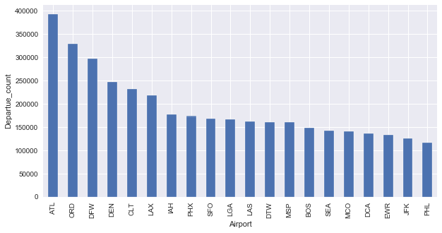

```python
air_time[air_time['CANCELLED']!=1.0]['ORIGIN'].value_counts().nlargest(20).plot.bar(figsize=(10,5))
air_time[air_time['CANCELLED']!=1.0]['DEST'].value_counts().nlargest(20).plot.bar(figsize=(10,5))
plt.ylabel('Departue_count')
plt.xlabel('Airport')
```

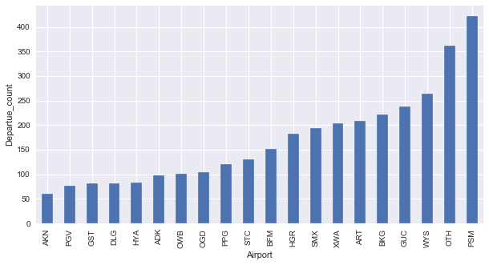

```python
air_time[air_time['CANCELLED']!=1.0]['ORIGIN'].value_counts().nsmallest(20).plot.bar(figsize=(10,5))
plt.ylabel('Departue_count')
plt.xlabel('Airport')
```

AKN is the least busy airport in terms of flight departures with just about 60 flights followed by PGV DLG.

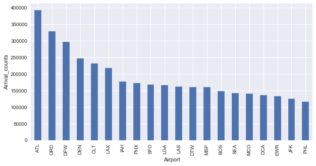

```python
air_time[air_time['CANCELLED']!=1.0]['DEST'].value_counts().nlargest(20).plot.bar(figsize=(10,5))
plt.ylabel('Arrival_counts')
plt.xlabel('Airport')
```

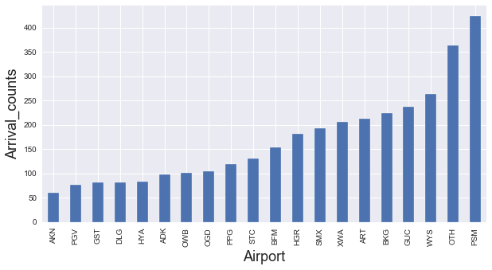

```python
air_time[air_time['CANCELLED']!=1.0]['DEST'].value_counts().nsmallest(20).plot.bar(figsize=(10,5))
plt.ylabel('Arrival_counts',fontsize=18)
plt.xlabel('Airport',fontsize=18)
```

AKN is the least busy airport in terms of flight arrivals with just about 60 flights followed by PGV DLG.

When we combine both arrival ad departure for each airport it looks like a 50:50 ratio, which might most likely be because most of the trips are round trips.

```python
air_time['DAY'].value_counts(sort=True)
```

```
Mon     1107285
Fri     1103049
Thur    1094899
Tues    1077957
Wed     1075379
Sun     1056723
Sat      906745
Name: DAY, dtype: int64
```

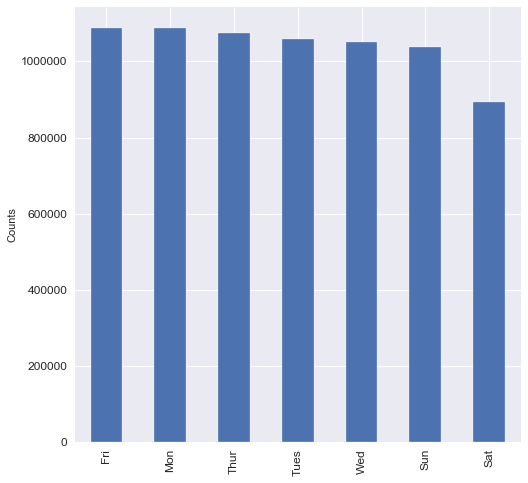

```python
air_time[air_time['CANCELLED']!=1.0]['DAY'].value_counts(sort=True).plot.bar(figsize=(8,8),fontsize=12)
plt.ylabel('Counts')
```

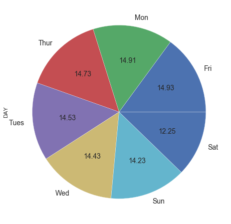

```python
air_time[air_time['CANCELLED']!=1.0]['DAY'].value_counts(sort=True).plot.pie(figsize=(8,8),autopct='%1.2f', textprops={'fontsize': 14})
```

Friday and Monday accounted for most travel. This is closely followed by Tues, wed and Sun which show activity level close to Friday and Monday. The high activity on friday and Monday would mostly be from those heading for or coming back from weekend holiday trips in other cities, states or countries.

What percentage of the scheduled flights were Cancelled?

```python
air_time["FLIGHT STATUS"] = air_time['CANCELLED'].replace([1,0],['Cancelled','Not Cancelled'])
```

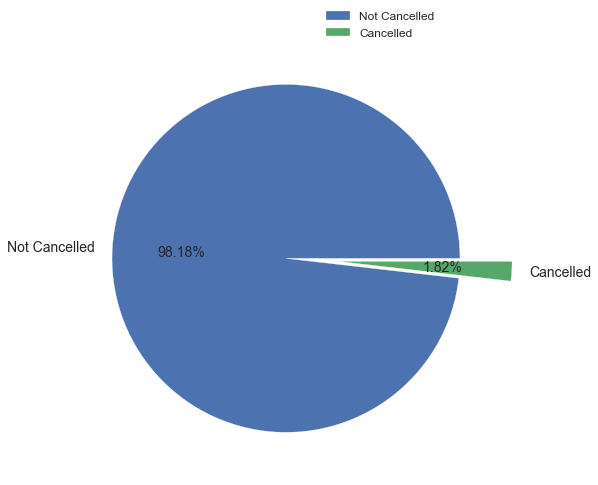

```python
plt.figure(figsize=(8,8))
plt.pie(air_time['CANCELLED'].value_counts(),autopct='%1.2f%%',labels=['Not Cancelled','Cancelled'],explode=[0.2,0.1],textprops={'fontsize': 14})
plt.legend(fontsize=12,loc=(0.5,1))
```

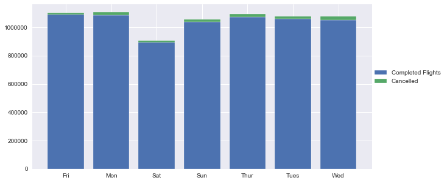

```python
plt.figure(figsize=(10,5))
plt.bar(air_time[air_time['CANCELLED']!=1].groupby(['DAY'])['CANCELLED'].count().index,air_time[air_time['CANCELLED']!=1].groupby(['DAY'])['CANCELLED'].count(),label='Completed Flights')
plt.bar(air_time[air_time['CANCELLED']==1].groupby(['DAY'])['CANCELLED'].count().index,air_time[air_time['CANCELLED']==1].groupby(['DAY'])['CANCELLED'].count(),bottom=air_time[air_time['CANCELLED']!=1].groupby(['DAY'])['CANCELLED'].count(),label='Cancelled')
plt.legend(loc=(1,0.5))
```

Over 98% of the scheduled flight were completed, while 1.82% were cancelled.

Which airports recorded the highest number of arrival and departure delays delay?

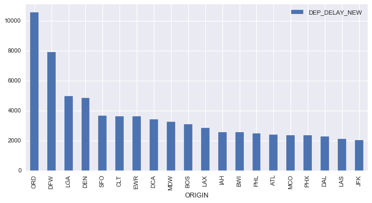

```python
air_time[air_time['DEP_DELAY_NEW']>0].groupby('ORIGIN')[['DEP_DELAY_NEW']].count().nlargest(20,'DEP_DELAY_NEW').plot.bar(figsize=(10,5))
```

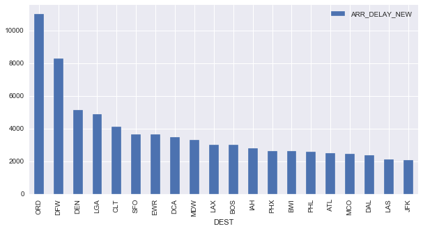

```python
air_time[air_time['ARR_DELAY_NEW']>0].groupby('DEST')[['ARR_DELAY_NEW']].count().nlargest(20,'ARR_DELAY_NEW').plot.bar(figsize=(10,5))
```

##### Looking at Airline how airline faired closely.

What is the stake of each airline in the aviation sector in 2019

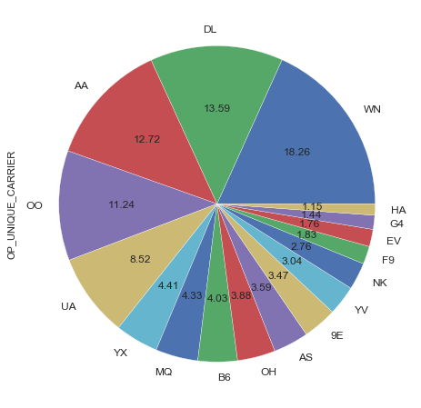

```python
plt.figure(figsize=(8,8))
air_time[air_time['CANCELLED']!=1.0]['OP_UNIQUE_CARRIER'].value_counts().plot.pie(autopct='%1.2f', fontsize=12)
```

WN recorded the most activity in terms of flight activity in 2019. This is followed by DL, AA and 00. The least activity was recorded by HA.

```python
plt.rcParams.update({'axes.labelsize': 16.0,'font.size': 14.0})
```

```python
air_time[air_time['CANCELLED']==1].groupby('OP_UNIQUE_CARRIER',as_index=False)['CANCELLED'].count().sort_values(['OP_UNIQUE_CARRIER'])
```

|  | OP_UNIQUE_CARRIER | CANCELLED |
| --- | --- | --- |
| 0 | 9E | 4257 |
| 1 | AA | 20151 |
| 2 | AS | 3077 |
| 3 | B6 | 3764 |
| 4 | DL | 1842 |
| 5 | EV | 6086 |
| 6 | F9 | 2281 |
| 7 | G4 | 624 |
| 8 | HA | 137 |
| 9 | MQ | 11430 |
| 10 | NK | 3590 |
| 11 | OH | 6826 |
| 12 | OO | 17453 |
| 13 | UA | 5384 |
| 14 | WN | 33622 |
| 15 | YV | 6709 |
| 16 | YX | 7692 |

Which airline covered the most distance and the most airtime

```python
zz=air_time[air_time['CANCELLED']!=1.0].groupby('OP_UNIQUE_CARRIER',as_index=False,sort=True)['DISTANCE','AIR_TIME'].sum()
```

[output not shown]

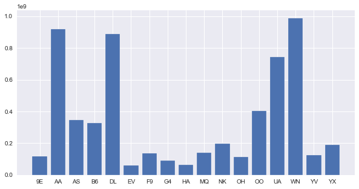

```python
plt.figure(figsize=(10,5))
plt.bar(zz['OP_UNIQUE_CARRIER'],zz['DISTANCE'])
```

```
<BarContainer object of 17 artists>
```

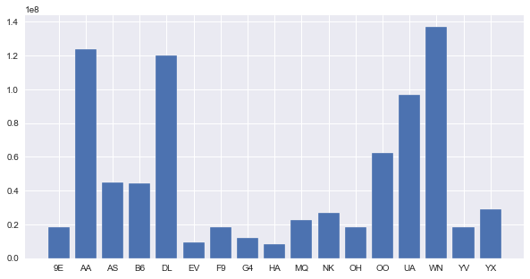

```python
plt.figure(figsize=(10,5))
plt.bar(zz['OP_UNIQUE_CARRIER'],zz['AIR_TIME'])
```

WN has the largest mileage and airtime. this is followed by AA, DL and UA. Airtime and distance covered show very similar trend

How does cancelled flight compare to successful flights?

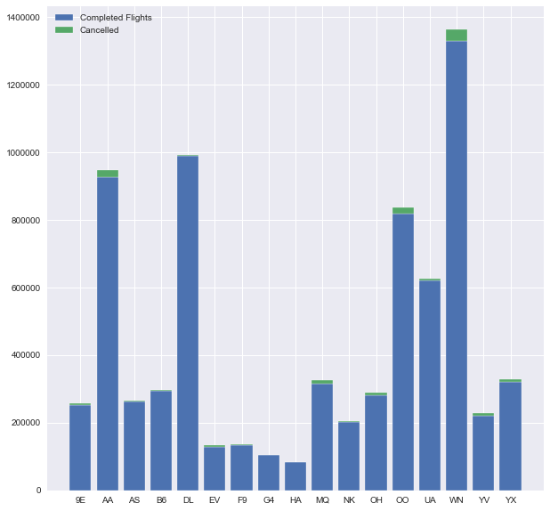

```python
plt.figure(figsize=(10,10))
plt.bar(air_time[air_time['CANCELLED']!=1].groupby(['OP_UNIQUE_CARRIER'])['CANCELLED'].count().index,air_time[air_time['CANCELLED']!=1].groupby(['OP_UNIQUE_CARRIER'])['CANCELLED'].count(),label='Completed Flights')
plt.bar(air_time[air_time['CANCELLED']==1].groupby(['OP_UNIQUE_CARRIER'])['CANCELLED'].count().index,air_time[air_time['CANCELLED']==1].groupby(['OP_UNIQUE_CARRIER'])['CANCELLED'].count(),bottom=air_time[air_time['CANCELLED']!=1].groupby(['OP_UNIQUE_CARRIER'])['CANCELLED'].count(),label='Cancelled')
plt.legend()
```

```python
air_time['CANCELLATION_CODE'].value_counts()
```

```
B    72277
A    37854
C    24775
D       19
Name: CANCELLATION_CODE, dtype: int64
```

What is the major source of cancellation

```
<BarContainer object of 4 artists>
```

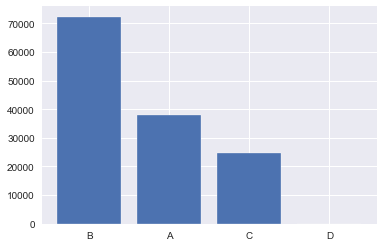

```python
plt.bar(air_time['CANCELLATION_CODE'].value_counts().index,air_time['CANCELLATION_CODE'].value_counts())
```

A-Carrier, B- Weather, C- National Air System, D- Security

Most cancellation were as a result of weather issues which are natural and instruments available can guarantee smooth flying. This is followed by Carrier issues which are mostly associated with extreme cases where airlines not been able to meet up for scheduled flights even when they are delayed.

Having looked at causes of cancellation, what could be the reason for flight delays

```python
air_time
```

[output not shown]

[output cut: 471 more lines]

7422037 rows × 37 columns

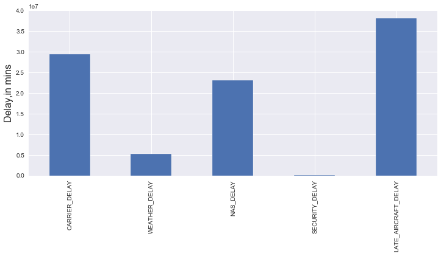

```python
plt.figure(figsize=(12,5))
air_time.loc[:,['CARRIER_DELAY', 'WEATHER_DELAY', 'NAS_DELAY',
       'SECURITY_DELAY', 'LATE_AIRCRAFT_DELAY']].sum().plot.bar()
plt.ylabel("Delay,in mins")
```

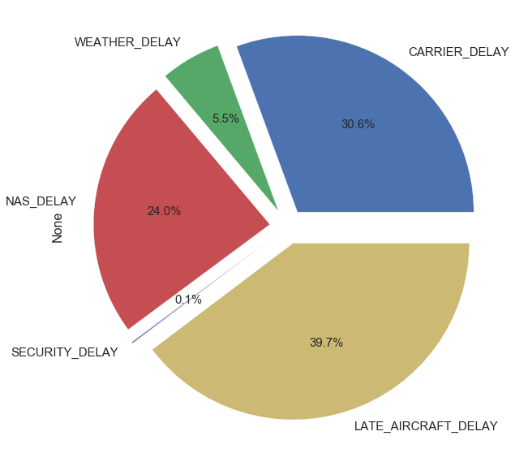

```python
plt.figure(figsize=(10,10))
air_time.loc[:,['CARRIER_DELAY', 'WEATHER_DELAY', 'NAS_DELAY',
       'SECURITY_DELAY', 'LATE_AIRCRAFT_DELAY']].sum().plot.pie(autopct='%1.1f%%',explode=(0.1,0.1,0.1,0.1,0.1),textprops={'fontsize':15})
```

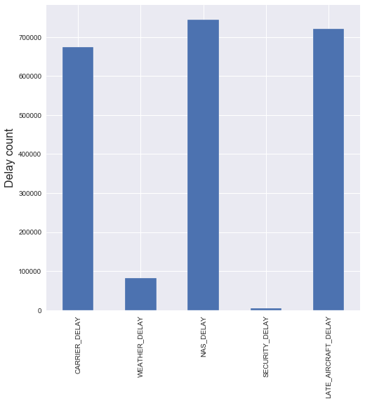

```python
plt.figure(figsize=(8,8))
air_time.loc[:,['CARRIER_DELAY', 'WEATHER_DELAY', 'NAS_DELAY',
       'SECURITY_DELAY', 'LATE_AIRCRAFT_DELAY']].count(numeric_only=True).plot.bar()

plt.ylabel("Delay count")
```

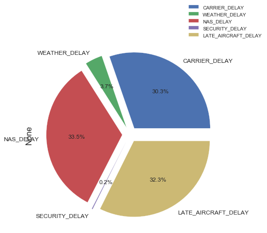

```python
plt.figure(figsize=(7,7))
air_time.loc[:,['CARRIER_DELAY', 'WEATHER_DELAY', 'NAS_DELAY',
       'SECURITY_DELAY', 'LATE_AIRCRAFT_DELAY']].count(numeric_only=True).plot.pie(autopct='%1.1f%%',explode=(0.1,0.1,0.1,0.1,0.1),textprops={'fontsize':12})

plt.legend(loc=(0.8,1))
```

National Aviation System (NAS) account for most delays amd it associated with several condition which include non-extreme weather conditions, airport operations, heavy traffic volume, and air traffic control.

NAS delay is closely followed by Flight delays associated with Late Aircraft which also account the longest delay time

Since most flights operate round trips a delay for any other reason will affect subsequent departure or arrival of the flight givig rise to late aircraft delays. Ignoring late aircraft delay issues since it is dependent mostly on other delays, Carrier delays would have have actually account for the longest delays. Improving efficiency in airline operations would actually reduce late aircraft delays time.

If daily schedules are also maintained by airline, NAS delay count will most likely be reduced to minimal.

Weather had a minimal contribution to delays compared to cancellations. Meaning weather issues lead to outright cancellation outright cancellation of flights.

This would be an interest area for further investigation.

```python
yy=air_time[air_time['CANCELLED']!=1.0].groupby(['OP_UNIQUE_CARRIER'],as_index=False)[['CARRIER_DELAY', 'WEATHER_DELAY', 'NAS_DELAY',
       'SECURITY_DELAY', 'LATE_AIRCRAFT_DELAY']].count()
yy.tail()
```

|  | OP_UNIQUE_CARRIER | CARRIER_DELAY | WEATHER_DELAY | NAS_DELAY | SECURITY_DELAY | LATE_AIRCRAFT_DELAY |
| --- | --- | --- | --- | --- | --- | --- |
| 12 | OO | 51237 | 11474 | 78524 | 344 | 83934 |
| 13 | UA | 53314 | 9959 | 80769 | 44 | 60951 |
| 14 | WN | 147886 | 6224 | 93421 | 1136 | 150260 |
| 15 | YV | 19918 | 3731 | 16776 | 171 | 22391 |
| 16 | YX | 20574 | 3448 | 41368 | 160 | 30498 |

```python
yy.sum()
```

```
OP_UNIQUE_CARRIER      9EAAASB6DLEVF9G4HAMQNKOHOOUAWNYVYX
CARRIER_DELAY                                      674713
WEATHER_DELAY                                       82237
NAS_DELAY                                          745235
SECURITY_DELAY                                       4531
LATE_AIRCRAFT_DELAY                                720363
dtype: object
```

```python
yz=air_time[air_time['CANCELLED']!=1.0].groupby(['OP_UNIQUE_CARRIER'],as_index=False)[['CARRIER_DELAY', 'WEATHER_DELAY', 'NAS_DELAY',
       'SECURITY_DELAY', 'LATE_AIRCRAFT_DELAY']].sum()
yz.tail()
```

|  | OP_UNIQUE_CARRIER | CARRIER_DELAY | WEATHER_DELAY | NAS_DELAY | SECURITY_DELAY | LATE_AIRCRAFT_DELAY |
| --- | --- | --- | --- | --- | --- | --- |
| 12 | OO | 4599093.0 | 1124530.0 | 2371100.0 | 14599.0 | 4847545.0 |
| 13 | UA | 2137677.0 | 603802.0 | 3103937.0 | 1794.0 | 4145616.0 |
| 14 | WN | 4104804.0 | 340224.0 | 2001012.0 | 44881.0 | 5605842.0 |
| 15 | YV | 1275476.0 | 311986.0 | 492172.0 | 3364.0 | 1697726.0 |
| 16 | YX | 867103.0 | 199471.0 | 1571102.0 | 3877.0 | 1654124.0 |

```python
yy.mean()
```

```
CARRIER_DELAY          39689.000000
WEATHER_DELAY           4837.470588
NAS_DELAY              43837.352941
SECURITY_DELAY           266.529412
LATE_AIRCRAFT_DELAY    42374.294118
dtype: float64
```

How do the airline fair in terms of delays?

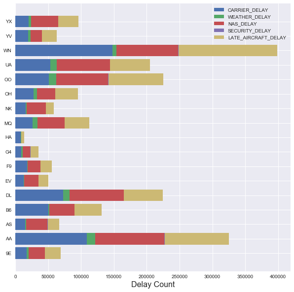

```python
fig,ax=plt.subplots(figsize=(10,10))

plt.barh(yy['OP_UNIQUE_CARRIER'],yy['CARRIER_DELAY'],label='CARRIER_DELAY',linewidth=0)
plt.barh(yy['OP_UNIQUE_CARRIER'],yy['WEATHER_DELAY'],left=list(np.sum(yy.iloc[:,1:2],axis=1)),label='WEATHER_DELAY',linewidth=0)
plt.barh(yy['OP_UNIQUE_CARRIER'],yy['NAS_DELAY'],left=list(np.sum(yy.iloc[:,1:3],axis=1)),label='NAS_DELAY',linewidth=0)
plt.barh(yy['OP_UNIQUE_CARRIER'],yy['SECURITY_DELAY'],left=list(np.sum(yy.iloc[:,1:4],axis=1)),label='SECURITY_DELAY',linewidth=0)
plt.barh(yy['OP_UNIQUE_CARRIER'],yy['LATE_AIRCRAFT_DELAY'],left=list(np.sum(yy.iloc[:,1:5],axis=1)),label='LATE_AIRCRAFT_DELAY',linewidth=0)

plt.legend()
plt.xlabel('Delay Count')
```

WN has the most number of delays(as also seen earlier it is also very well known to have the higest amount of cancellations). Although, DL is the second most active airline, it has delays number lower than AA which has a lower activity compared to DL.

In most cases, the count due to carrier delays mirror delays due to late arrival. Support the facts that most flights make round trips and a delay delay will affect subsequent schedules.

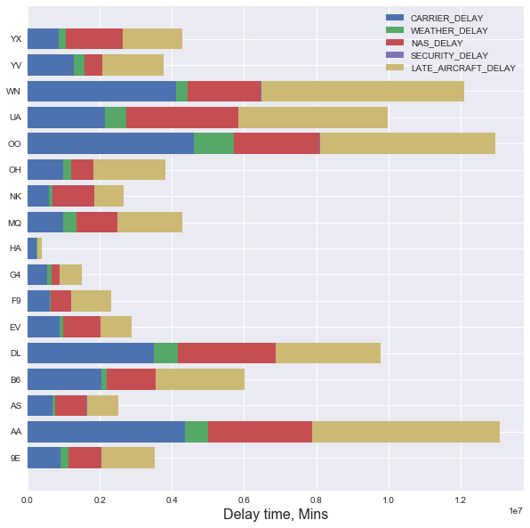

```python
fig,ax=plt.subplots(figsize=(10,10))

plt.barh(yz['OP_UNIQUE_CARRIER'],yz['CARRIER_DELAY'],label='CARRIER_DELAY',linewidth=0)
plt.barh(yz['OP_UNIQUE_CARRIER'],yz['WEATHER_DELAY'],left=list(np.sum(yz.iloc[:,1:2],axis=1)),label='WEATHER_DELAY',linewidth=0)
plt.barh(yz['OP_UNIQUE_CARRIER'],yz['NAS_DELAY'],left=list(np.sum(yz.iloc[:,1:3],axis=1)),label='NAS_DELAY',linewidth=0)
plt.barh(yz['OP_UNIQUE_CARRIER'],yz['SECURITY_DELAY'],left=list(np.sum(yz.iloc[:,1:4],axis=1)),label='SECURITY_DELAY',linewidth=0)
plt.barh(yz['OP_UNIQUE_CARRIER'],yz['LATE_AIRCRAFT_DELAY'],left=list(np.sum(yz.iloc[:,1:5],axis=1)),label='LATE_AIRCRAFT_DELAY',linewidth=0)



plt.legend()
plt.xlabel('Delay time, Mins')
```

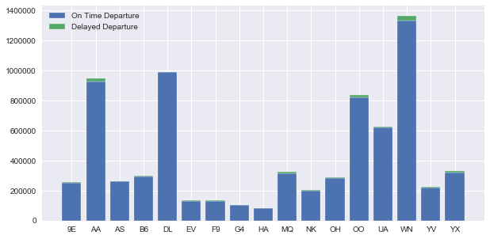

```python
plt.figure(figsize=(10,5))
plt.bar(air_time[air_time['DEP_DELAY_NEW']==0].groupby(['OP_UNIQUE_CARRIER'])['DEP_DELAY_NEW'].count().index,air_time[air_time['DEP_DELAY_NEW']==0].groupby(['OP_UNIQUE_CARRIER'])['DEP_DELAY_NEW'].count(),label='On Time Departure')
plt.bar(air_time[air_time['DEP_DELAY_NEW']>0].groupby(['OP_UNIQUE_CARRIER'])['DEP_DELAY_NEW'].count().index,air_time[air_time['DEP_DELAY_NEW']>0].groupby(['OP_UNIQUE_CARRIER'])['DEP_DELAY_NEW'].count(),bottom=air_time[air_time['DEP_DELAY_NEW']==0].groupby(['OP_UNIQUE_CARRIER'])['DEP_DELAY_NEW'].count(),label='Delayed Departure')
plt.legend()
```

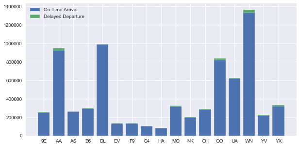

```python
plt.figure(figsize=(10,5))
plt.bar(air_time[air_time['ARR_DELAY_NEW']==0].groupby(['OP_UNIQUE_CARRIER'])['ARR_DELAY_NEW'].count().index,air_time[air_time['ARR_DELAY_NEW']==0].groupby(['OP_UNIQUE_CARRIER'])['ARR_DELAY_NEW'].count(),label='On Time Arrival')
plt.bar(air_time[air_time['ARR_DELAY_NEW']>0].groupby(['OP_UNIQUE_CARRIER'])['ARR_DELAY_NEW'].count().index,air_time[air_time['ARR_DELAY_NEW']>0].groupby(['OP_UNIQUE_CARRIER'])['ARR_DELAY_NEW'].count(),bottom=air_time[air_time['ARR_DELAY_NEW']==0].groupby(['OP_UNIQUE_CARRIER'])['ARR_DELAY_NEW'].count(),label='Delayed Departure')
plt.legend()
```

```python
xx=air_time.groupby('MONTH',as_index=False)[['CARRIER_DELAY', 'WEATHER_DELAY', 'NAS_DELAY',
       'SECURITY_DELAY', 'LATE_AIRCRAFT_DELAY']].count()
```

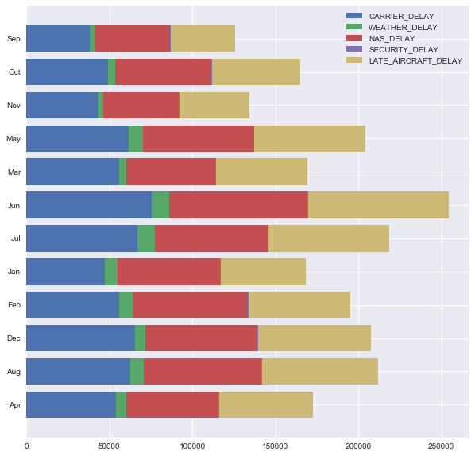

```python
fig,ax=plt.subplots(figsize=(10,10))

plt.barh(xx['MONTH'],xx['CARRIER_DELAY'],label='CARRIER_DELAY',linewidth=0)
plt.barh(xx['MONTH'],xx['WEATHER_DELAY'],left=list(np.sum(xx.iloc[:,1:2],axis=1)),label='WEATHER_DELAY',linewidth=0)
plt.barh(xx['MONTH'],xx['NAS_DELAY'],left=list(np.sum(xx.iloc[:,1:3],axis=1)),label='NAS_DELAY',linewidth=0)
plt.barh(xx['MONTH'],xx['SECURITY_DELAY'],left=list(np.sum(xx.iloc[:,1:4],axis=1)),label='SECURITY_DELAY',linewidth=0)
plt.barh(xx['MONTH'],xx['LATE_AIRCRAFT_DELAY'],left=list(np.sum(xx.iloc[:,1:5],axis=1)),label='LATE_AIRCRAFT_DELAY',linewidth=0)



plt.legend()
```

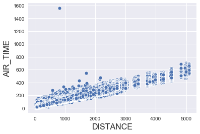

```python
sns.scatterplot(x=air_time['DISTANCE'],y=air_time['AIR_TIME'])
```

```python
air_time[air_time['OP_UNIQUE_CARRIER']=='DL']['ORIGIN'].value_counts().nlargest(5)
```

```
ATL    244078
MSP     68576
DTW     59820
SLC     47002
LAX     36498
Name: ORIGIN, dtype: int64
```

```python
air_time[air_time['OP_UNIQUE_CARRIER']=='WN']['ORIGIN'].value_counts().nlargest(5)
```

```
MDW    78506
DEN    71624
LAS    70901
BWI    70321
DAL    68490
Name: ORIGIN, dtype: int64
```

air_time.to_csv('air_time1.csv')

```python
air_time.groupby('OP_UNIQUE_CARRIER')['CANCELLATION_CODE','OP_UNIQUE_CARRIER'].count()
```

| OP_UNIQUE_CARRIER | CANCELLATION_CODE | OP_UNIQUE_CARRIER |
| --- | --- | --- |
| 9E | 4257 | 257132 |
| AA | 20151 | 946776 |
| AS | 3077 | 264816 |
| B6 | 3764 | 297411 |
| DL | 1842 | 991986 |
| EV | 6086 | 134683 |
| F9 | 2281 | 135543 |
| G4 | 624 | 105305 |
| HA | 137 | 83891 |
| MQ | 11430 | 327007 |
| NK | 3590 | 204845 |
| OH | 6826 | 289304 |
| OO | 17453 | 836445 |
| UA | 5384 | 625910 |
| WN | 33622 | 1363946 |
| YV | 6709 | 227888 |
| YX | 7692 | 329149 |